# Exploring seasonal biodiversity differences in dairy samples across a processing pipeline

Kailyn Hanke

2025-04-26

# Goals

The goal of this document is to run an analysis on the within-sample biodiversity of the samples in my project, similar to the analysis that I ran in 05_Biodiversity. This is the first of three new analysis documents I will make (I will subsequently make 09_Seasonality_Ordination and 10_Seasonality_Composition).

**With these three additional documents I want to determine if season can explain the weird distinct clustering I was seeing within Skim Milk Powder samples in my ordinations, as well the bimodal distribution in my relative abundance taxa plots! I hope to be able to explore what is driving these differences!**

When I initially completed my homework assignments, I ran my biodiversity, ordination and composition analysis without splitting my data up between mid-lactation and late-lactation samples (sample seasonality). This was a great starting point, but for my presentation and to wrap up this project, I really wanted to run additional analysis where I also consider the “seasonality” of my samples to mimic the analysis done in the paper where this data is originally from (McHugh et al. 2020). Just slipped that in there to practice making citations and bibliographies in RMarkdown :)

I thought that making separate analysis documents was probably the best way to maintain organization within my project, while providing me with a little piece of mind I would not mess up the analysis I did in my original homework documents. It’s super cool that I have the skills to do this - hopefully my organization and reproducibility continue to improve while I work on these documents!

In this document I do not need to calculate Hill Numbers or evaluate the rarefaction curves, as I have previously done this in my original homework document!

1. Analyze the Hill numbers as it relates to sample type across processing pipeline and seasonality.
2. Test and answer additional scientific questions focused on seasonality and sample type!

One last thing I want to note is that these three new documents focused on seasonality are primarily just for exploratory analysis, I likely will not comment/complete analysis, intro/conclusion on all of the plots/work I do! Just wanted to fit them in as a little bonus analysis.

1. We will need the `midpoint_rooted_physeq_cut`, the midpoint rooted tree that we initially created in `analysis/04B_Phylogenetic_Tree_Inspection.Rmd`, but was edited in my original homework document `analysis/05_Biodiversity.Rmd`. We will also need to load in some other objects from that original document since we are skipping straight to our diversity analyses (see the load data chunk).

## Outputs

1. Figures to include in our scientific paper that visualize the data as it relates to the scientific question.
2. Statistical tests conveying the measured and quantified changes and patterns in biodiversity.

# Set up the environment

## Timing of this script

```r
# What time did we start running this script?
start_time <- Sys.time()
```

## Set the seed

```r
set.seed(111111)
```

## Load Packages & Colors

```r
#install packages for stats
#install.packages("rstatix")
#install.packages("ggpubr")
#install.packages("FSA")
#install.packages("rstatix")
#install.packages("lubridate")


pacman::p_load(tidyverse, devtools, patchwork, iNEXT, phyloseq, lubridate,
               # packages for stats
               ggpubr, rstatix, FSA, install = FALSE)
```

## Load in Data

```r
load("data/05_Biodiversity/midpoint_rooted_physeq_cut.RData")

load("data/05_Biodiversity/obs_div_df_cut.RData")

source("code/colors.R")
```

# Diversity by Sample Type

## Determing mid-lactation and late-lactation

```r
#Extract the month to determine mid-lactation and late-lactation samples


#changing the formatting of Collection_Date
obs_div_df_cut <- obs_div_df_cut %>%
  mutate(Collection_Date = mdy(Collection_Date))

#Extracting the month name
obs_div_df_cut <- obs_div_df_cut %>%
  mutate(month_name = month(Collection_Date, label = TRUE))

#Count how many samples were collected each month
obs_div_df_cut %>%
  count(month_name)
```

```
##   month_name   n
## 1        Jan  27
## 2        May 300
## 3        Oct 201
## 4        Dec  48
```

```r
# Add numeric month and season column so that obs_div_df_cut will have month_name (May), month (5) and seasonality (mid_lactation)

obs_div_df_cut <- obs_div_df_cut %>%
  mutate(
    month = month(Collection_Date), # numeric month (1–12)
    season = case_when(
      month %in% c(5) ~ "mid_lactation",
      month %in% c(1, 10, 12) ~ "late_lactation",
      TRUE ~ NA_character_
    )
  )


#Intuition check

#check season counts
obs_div_df_cut %>%
  count(season)
```

```
##           season   n
## 1 late_lactation 276
## 2  mid_lactation 300
```

Okay nice, I successfully incorporated seasonality into my df! As an intuition check I investigated to see if my month count and season count added up to the same value - and they did! Love to see it!

Note, mid-lactation samples were collected in May, while late-lactation samples were collected primarily in October, although due to farm scheduling, other samples were collected in December and January as well. The same 67 farms were re-sampled in the late-lactation period that were collected in the mid-lactation period.

Now we are going to look at diversity by sample type and collection season.

### Diversity by Sample Type

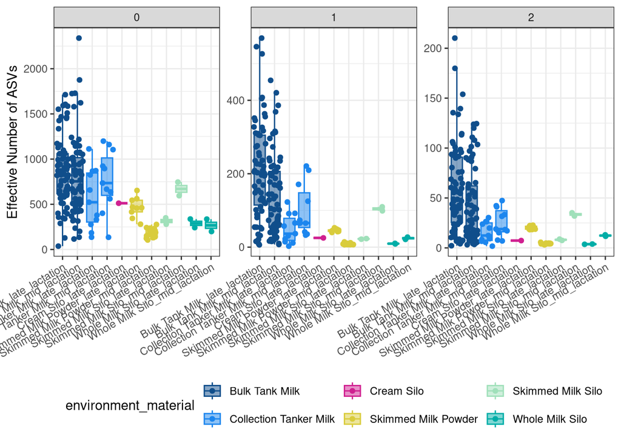

```r
# First, make a new variable combining environment_material and season
obs_div_df_cut <- obs_div_df_cut %>%
  mutate(env_season = paste(environment_material, season, sep = "_"))


# Now plot!
obs_div_df_cut %>%
  ggplot(aes(x = env_season, y = qD, fill = environment_material, color = environment_material)) +
  facet_wrap(.~Order.q, scales = "free_y") +
  geom_jitter() +
  geom_boxplot(alpha = 0.5, outlier.shape = NA) +
  scale_color_manual(values = environment_colors) +
  scale_fill_manual(values = environment_colors) +
  labs(y = "Effective Number of ASVs") +
  theme_bw() +
  theme(legend.position = "bottom",
        axis.title.x = element_blank(),
        axis.text.x = element_text(angle = 30, hjust = 1, vjust = 1))
```

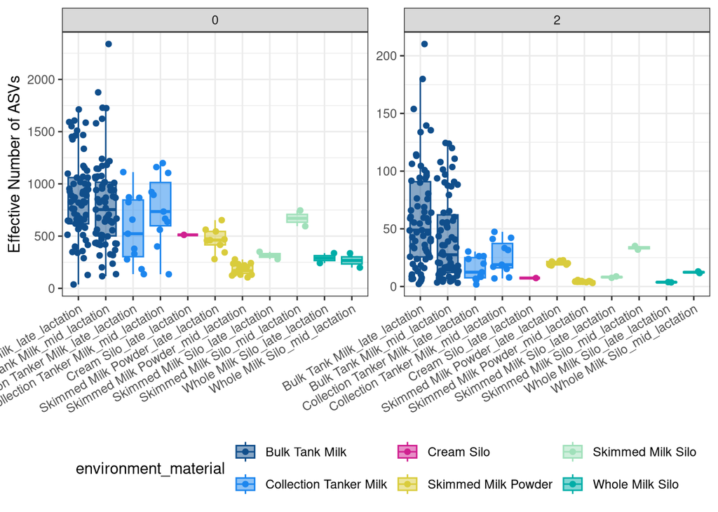

```r
# Now plot!
obs_div_df_cut %>%
  filter(Order.q %in% c(0, 2)) %>%
  ggplot(aes(x = env_season, y = qD, fill = environment_material, color = environment_material)) +
  facet_wrap(.~Order.q, scales = "free_y") +
  geom_jitter() +
  geom_boxplot(alpha = 0.5, outlier.shape = NA) +
  scale_color_manual(values = environment_colors) +
  scale_fill_manual(values = environment_colors) +
  labs(y = "Effective Number of ASVs") +
  theme_bw() +
  theme(legend.position = "bottom",
        axis.title.x = element_blank(),
        axis.text.x = element_text(angle = 30, hjust = 1, vjust = 1))
```

# Statistically Test Richness

```r
#Use this chunk to run stats on richness between mid- and late-lactation FOR EACH SAMPLE TYPE

#This mimics the setup of Fig 2A in my paper

#We need to use not normal test

# Pull out richness data
obs_rich_df_cut <-
  obs_div_df_cut %>%
  dplyr::filter(Order.q == 0)


#Reorder sample type levels
obs_rich_df_cut$environment_material <- factor(
  obs_rich_df_cut$environment_material,
  levels = c("Bulk Tank Milk", "Collection Tanker Milk", "Whole Milk Silo", "Cream Silo", "Skimmed Milk Silo",
             "Skimmed Milk Powder")
)


# Remove 'Cream Silo' samples just for Wilcoxon testing
richness_no_cream <- obs_rich_df_cut %>%
  filter(environment_material != "Cream Silo")


#Perform Wilcoxon Rank-Sum test: richness between seasons, separately for each sample type

wilcox_season_richness <- richness_no_cream %>%
  group_by(environment_material) %>%
  rstatix::wilcox_test(qD ~ season)


# Look at it
wilcox_season_richness
```

```
## # A tibble: 5 × 8
##   environment_material   .y.   group1       group2    n1    n2 statistic       p
## * <fct>                  <chr> <chr>        <chr>  <int> <int>     <dbl>   <dbl>
## 1 Bulk Tank Milk         qD    late_lactat… mid_l…    67    67      2484 2.88e-1
## 2 Collection Tanker Milk qD    late_lactat… mid_l…    11    11        38 1.51e-1
## 3 Whole Milk Silo        qD    late_lactat… mid_l…     2     2         3 6.67e-1
## 4 Skimmed Milk Silo      qD    late_lactat… mid_l…     2     2         0 3.33e-1
## 5 Skimmed Milk Powder    qD    late_lactat… mid_l…     9    18       162 3.46e-5
```

Note that to do my Wilcoxon test for non-normal data, I had to remove my cream silo sample because there was only one sample taken during the late-lactation phase.

Also note that when I was statistically testing for richness in my original 05_Biodiversity document, I used a Kruskal Wallis test since I was comparing richness differences between all the different sample types at once. Here I used Wilcoxon test, since only comparing the difference in richness within the mid/late lactation groups.

From the results of the Wilcoxon test, the only sample type with a significant difference in richness between mid- and late-lactation samples was Skimmed Milk Powder samples (had p-value < 0.05).

# Statistically Test Shannon Diversity

```r
#Use this chunk to run stats on shannon diversity between mid- and late-lactation FOR EACH SAMPLE TYPE

#This mimics the setup of Fig 2A in my paper

#Right now, would need to use not normal test

# Pull out shannon diversity data
obs_shannon_df_cut <-
  obs_div_df_cut %>%
  dplyr::filter(Order.q == 1)


#Reorder sample type levels
obs_shannon_df_cut$environment_material <- factor(
  obs_shannon_df_cut$environment_material,
  levels = c("Bulk Tank Milk", "Collection Tanker Milk", "Whole Milk Silo", "Cream Silo", "Skimmed Milk Silo",
             "Skimmed Milk Powder")
)


# Remove 'Cream Silo' samples just for Wilcoxon testing
shannon_no_cream <- obs_shannon_df_cut %>%
  filter(environment_material != "Cream Silo")


#Perform Wilcoxon Rank-Sum test: shannon diversity between seasons, separately for each sample type
wilcox_season_shannon <- shannon_no_cream %>%
  group_by(environment_material) %>%
  wilcox_test(qD ~ season)


# Look at it
wilcox_season_shannon
```

```
## # A tibble: 5 × 8
##   environment_material   .y.   group1       group2    n1    n2 statistic       p
## * <fct>                  <chr> <chr>        <chr>  <int> <int>     <dbl>   <dbl>
## 1 Bulk Tank Milk         qD    late_lactat… mid_l…    67    67      2939 2.01e-3
## 2 Collection Tanker Milk qD    late_lactat… mid_l…    11    11        32 6.52e-2
## 3 Whole Milk Silo        qD    late_lactat… mid_l…     2     2         0 3.33e-1
## 4 Skimmed Milk Silo      qD    late_lactat… mid_l…     2     2         0 3.33e-1
## 5 Skimmed Milk Powder    qD    late_lactat… mid_l…     9    18       162 4.27e-7
```

From the results of the Wilcoxon test, Skimmed Milk Powder samples and Bulk Tank Milk samples had a significant difference in shannon diversity between mid and late-lactation samples (had p-value < 0.05).

# Statistically Test Simpson Diversity

```r
#Use this chunk to run stats on simpson diversity between mid- and late-lactation FOR EACH SAMPLE TYPE

#This mimics the setup of Fig 2A in my paper

#Right now, would need to use not normal test

# Pull out simpson diversity data
obs_simpson_df_cut <-
  obs_div_df_cut %>%
  dplyr::filter(Order.q == 2)


#Reorder sample type levels
obs_simpson_df_cut$environment_material <- factor(
  obs_shannon_df_cut$environment_material,
  levels = c("Bulk Tank Milk", "Collection Tanker Milk", "Whole Milk Silo", "Cream Silo", "Skimmed Milk Silo",
             "Skimmed Milk Powder")
)


# Remove 'Cream Silo' samples just for Wilcoxon testing
simpson_no_cream <- obs_simpson_df_cut %>%
  filter(environment_material != "Cream Silo")


#Perform Wilcoxon Rank-Sum test: simpson diversity between seasons, separately for each sample type
wilcox_season_simpson <- simpson_no_cream %>%
  group_by(environment_material) %>%
  wilcox_test(qD ~ season)


# Look at it
wilcox_season_simpson
```

```
## # A tibble: 5 × 8
##   environment_material   .y.   group1       group2    n1    n2 statistic       p
## * <fct>                  <chr> <chr>        <chr>  <int> <int>     <dbl>   <dbl>
## 1 Bulk Tank Milk         qD    late_lactat… mid_l…    67    67      2824 9.98e-3
## 2 Collection Tanker Milk qD    late_lactat… mid_l…    11    11        36 1.16e-1
## 3 Whole Milk Silo        qD    late_lactat… mid_l…     2     2         0 3.33e-1
## 4 Skimmed Milk Silo      qD    late_lactat… mid_l…     2     2         0 3.33e-1
## 5 Skimmed Milk Powder    qD    late_lactat… mid_l…     9    18       162 4.27e-7
```

Like the Shannon diversity test, the results of the Wilcoxon test, Skimmed Milk Powder samples and Bulk Tank Milk samples had a significant difference in Simpson diversity between mid and late-lactation samples (had p-value < 0.05).

Below I originally tried to make a plot with my Wilcoxon richness test results added for richness, shannon and simpson diversity. Tried a few different things, but then decided to move onto other analysis, as I already had the stats results and just wanted to make a pretty visualization. I deleted my code because it didn’t work, but can see my past code attempts with my commit history in my Rmd.

# Final Thoughts

As a reminder, my primary scientific question was: How does the microbial diversity of dairy samples change throughout the skim milk powder manufacturing process?

And I had the following hypotheses:

- *Null Hypothesis:* Microbial alpha diversity (*e.g.* richness and Simpson diversity) does not vary as the raw milk is processed (as it goes from farm bulk tank milk to its final form of skim milk powder).
- *Alternative Hypothesis:* Microbial alpha diversity (*e.g.* richness and Simpson diversity) decreases as the raw milk is processed to become skim milk powder.

In my original ordinations (my PCoA and NMDS plots) I saw this weird distinct clustering of two groups within the SKimmed Milk Powder samples (as well as the Skimmed Milk Silo samples, although not as extreme). My hunch is that season will explain this odd clustering. By looking at these alpha diversity results, we can see that there are significant differences between the seasonal Skim Milk Powder samples. So it will be interesting when we look at microbial composition (using relative abundance of taxa) if we will see differences in seasonal Skim Milk Powder samples there.

If we see that season does seem to explain the weird clustering, the alpha diversity results we see here and potentially the composition results could help me reveal why we keep seeing these clustering patterns. I want to figure out what is driving this separation between Skimmed Milk Powder samples!!

# Final info for Reproducibility

## Check Render Time

```r
# Take the time now that we are at the end of the script
end_time <- Sys.time()
end_time
```

```
## [1] "2025-05-02 10:01:48 EDT"
```

```r
# Echo the elapsed time
elapsed_time <- round((end_time - start_time), 3)
elapsed_time
```

```
## Time difference of 9.661 secs
```

McHugh, Adam J., Conor Feehily, John T. Tobin, David Gleeson, Colin Hill, and Paul D. Cotter. 2020. “Tracking Dairy Microbiota from Farm Bulk Tank to Skim Milk Powder.” *mSystems* 5 (4): e00226–20. https://doi.org/10.1128/mSystems.00226-20.